# R Notebook

```r
library(tidyverse)
library(stringr)
library(phyloseq)
library(ggpubr)
library(DESeq2)
library(ALDEx2)
library(compositions)
```

Tidy up data

```r
## OTU TABLE
bracken_species_combined <- read.csv("data/metaG-taxonomy/bracken_species_combined.txt", sep="\t", header=T)
# Remove Xs
colnames(bracken_species_combined) <- sub("^X", "", colnames(bracken_species_combined))
# Split off data that just contains raw counts
bracken_species_combined_num <- bracken_species_combined %>%
  # the taxonomy IDs are completely different from the taxo table for some reason, so let's remove them
  dplyr::select(!c(contains("_frac"), taxonomy_lvl, taxonomy_id, "_num")) %>%
  dplyr::rename_all(~str_remove(., "_num")) %>%
  dplyr::rename(s=name) %>%
  # remove special characters and replace with _
  mutate(s = str_replace_all(s, "[^[:alnum:]]+", "_")) %>%
  # same with spaces
  mutate(s = str_replace_all(s, " ", "_")) %>%
  # remove _ at beginning or end of name
  mutate(s = str_replace_all(s, "^_+|_+$", "")) %>%
  column_to_rownames("s")

## TAXONOMY TABLE
taxonomy <- read.csv("data/metaG-taxonomy/taxonomy.tsv", sep="\t", header=F)
# This messy solution is required because of the bad strings
taxonomy_sep <- taxonomy %>%
  dplyr::select(!2) %>%
  mutate(d=str_extract(V1, "(?<=d__)[^|]+")) %>%
  mutate(k=str_extract(V1, "(?<=k__)[^|]+")) %>%
  mutate(p=str_extract(V1, "(?<=p__)[^|]+")) %>%
  mutate(c=str_extract(V1, "(?<=c__)[^|]+")) %>%
  mutate(o=str_extract(V1, "(?<=o__)[^|]+")) %>%
  mutate(f=str_extract(V1, "(?<=f__)[^|]+")) %>%
  mutate(g=str_extract(V1, "(?<=g__)[^|]+")) %>%
  mutate(s=str_extract(V1, "(?<=s__)[^|]+")) %>%
  dplyr::select(!V1)
# Narrow down to those present in data
taxonomy_sep_select <- taxonomy_sep %>%
  # remove special characters and replace with _
  mutate(s = str_replace_all(s, "[^[:alnum:]]+", "_")) %>%
  # same with spaces
  mutate(s = str_replace_all(s, " ", "_")) %>%
  # remove _ at beginning or end of name
  mutate(s = str_replace_all(s, "^_+|_+$", "")) %>%
  dplyr::filter(s %in% rownames(bracken_species_combined_num)) %>%
  # finally, filter for bacteria
  dplyr::filter(d=="Bacteria")
# remove duplicate rows, assign species as rownames, sort
taxonomy_sep_select <- unique(taxonomy_sep_select)
rownames(taxonomy_sep_select) <- taxonomy_sep_select$s

# update otu table such that only bacteria are present
bracken_species_combined_num <- bracken_species_combined_num[row.names(bracken_species_combined_num) %in% row.names(taxonomy_sep_select), ]
# put in same order
bracken_species_combined_num <- bracken_species_combined_num[match(row.names(taxonomy_sep_select), row.names(bracken_species_combined_num)), ]

#sanity check
setdiff(row.names(bracken_species_combined_num), row.names(taxonomy_sep_select))
```

```
character(0)
```

```r
# preview
head(bracken_species_combined_num)
```

|  | 0375TX | 0715RL | 0879UW | 1127XT | 1200QF | 1353XP | 1462QI | 1574UD | 1667SY | 1668QB | 1680RO | 1776HW | 1979HS | 2025XZ | 2221WA | 2423JT | 3364PX | 3523WP | 3553XK | 3606IJ | 3606MB | 3868PB | 4041OU | 4203AW | 4299EV | 4765DZ | 4815OY | 4846TW | 4928XR | … |
| --- | --- | --- | --- | --- | --- | --- | --- | --- | --- | --- | --- | --- | --- | --- | --- | --- | --- | --- | --- | --- | --- | --- | --- | --- | --- | --- | --- | --- | --- | --- |
| Pseudomonas_sp_StFLB209 | 42 | 18 | 0 | 28 | 70 | 48 | 120 | 11 | 0 | 0 | 18 | 15 | 36 | 0 | 0 | 37 | 82 | 0 | 30 | 0 | 0 | 40 | 15 | 137 | 0 | 0 | 42 | 0 | 23 | … |
| Pseudomonas_sp_DG56_2 | 34 | 10 | 14 | 36 | 24 | 31 | 40 | 0 | 0 | 0 | 20 | 0 | 0 | 13 | 0 | 0 | 41 | 0 | 0 | 0 | 0 | 17 | 11 | 142 | 15 | 0 | 13 | 0 | 15 | … |
| Pseudomonas_sp_M30_35 | 26 | 0 | 20 | 64 | 62 | 27 | 46 | 0 | 0 | 0 | 17 | 0 | 0 | 0 | 10 | 67 | 69 | 23 | 0 | 0 | 0 | 42 | 15 | 79 | 0 | 0 | 0 | 0 | 14 | … |
| Pseudomonas_sp_TCU_HL1 | 22 | 17 | 12 | 42 | 68 | 46 | 49 | 0 | 0 | 0 | 51 | 22 | 23 | 0 | 0 | 19 | 45 | 0 | 20 | 0 | 0 | 41 | 12 | 197 | 0 | 12 | 18 | 47 | 35 | … |
| Pseudomonas_sp_DY_1 | 36 | 26 | 0 | 100 | 69 | 38 | 833 | 0 | 40 | 0 | 20 | 18 | 14 | 0 | 0 | 23 | 80 | 0 | 16 | 0 | 0 | 29 | 13 | 98 | 0 | 0 | 15 | 11 | 30 | … |
| Pseudomonas_sp_SCB32 | 17 | 53 | 53 | 43 | 76 | 48 | 115 | 0 | 13 | 0 | 29 | 27 | 20 | 0 | 23 | 25 | 57 | 0 | 51 | 42 | 0 | 30 | 20 | 240 | 10 | 37 | 49 | 17 | 31 | … |

```r
head(taxonomy_sep_select)
```

|  | d | k | p | c | o | f | g | s |
| --- | --- | --- | --- | --- | --- | --- | --- | --- |
| Pseudomonas_sp_StFLB209 | Bacteria | NA | Proteobacteria | Gammaproteobacteria | Pseudomonadales | Pseudomonadaceae | Pseudomonas | Pseudomonas_sp_StFLB209 |
| Pseudomonas_sp_DG56_2 | Bacteria | NA | Proteobacteria | Gammaproteobacteria | Pseudomonadales | Pseudomonadaceae | Pseudomonas | Pseudomonas_sp_DG56_2 |
| Pseudomonas_sp_M30_35 | Bacteria | NA | Proteobacteria | Gammaproteobacteria | Pseudomonadales | Pseudomonadaceae | Pseudomonas | Pseudomonas_sp_M30_35 |
| Pseudomonas_sp_TCU_HL1 | Bacteria | NA | Proteobacteria | Gammaproteobacteria | Pseudomonadales | Pseudomonadaceae | Pseudomonas | Pseudomonas_sp_TCU_HL1 |
| Pseudomonas_sp_DY_1 | Bacteria | NA | Proteobacteria | Gammaproteobacteria | Pseudomonadales | Pseudomonadaceae | Pseudomonas | Pseudomonas_sp_DY_1 |
| Pseudomonas_sp_SCB32 | Bacteria | NA | Proteobacteria | Gammaproteobacteria | Pseudomonadales | Pseudomonadaceae | Pseudomonas | Pseudomonas_sp_SCB32 |

Import metadata

```r
GMCC_covariates_all_batches <- read.csv("data/metadata/GMCC_covariates_all_batches.csv", header=T)
# Identify missing samples
remove_from_abun <- setdiff(colnames(bracken_species_combined_num), GMCC_covariates_all_batches$SampleName)
remove_from_meta <- setdiff(GMCC_covariates_all_batches$SampleName, colnames(bracken_species_combined_num))
# Clean up metadata specific for this analysis
meta <- GMCC_covariates_all_batches %>%
  # remove underscores
  dplyr::mutate(SampleID = str_replace_all(SampleID, "_", "")) %>%
  dplyr::filter(!SampleName %in% remove_from_meta) %>%
  mutate(urbanism2=ifelse(country=="USA", "USA_urban", urbanism)) %>%
  mutate(SampleName2 = SampleName) %>%
  column_to_rownames("SampleName2") %>%
  mutate(shreya_samps = case_when(SampleName %in% c("6199II","4041OU","5905ZO","5744TZ","9261PK","8283LS","9794IK","6310FW") ~ "Selected",
                                  TRUE ~ "Other")) %>%
  dplyr::mutate(flag = case_when(
    country == "Ghana" ~ "data/metaG-QC/flags/ghana.svg",
    country == "Malaysia" ~ "data/metaG-QC/flags/malaysia.svg",
    country == "Nigeria" ~ "data/metaG-QC/flags/nigeria.svg",
    country == "Rwanda" ~ "data/metaG-QC/flags/rwanda.svg",
    country == "USA" ~ "data/metaG-QC/flags/usa.svg"))
```

Convert to phyloseq format

```r
 abun_phy <- bracken_species_combined_num %>%
    # Prune abundance table of samples missing from metadata
    dplyr::select(!all_of(remove_from_abun)) %>%
    as.matrix() %>%
    otu_table(taxa_are_rows = T)

tax_phy <- taxonomy_sep_select %>%
    as.matrix() %>%
    tax_table()

meta_phy <- sample_data(meta)

# run phyloseq
phy <- phyloseq(abun_phy, tax_phy, meta_phy)
phy
```

```
phyloseq-class experiment-level object
otu_table()   OTU Table:         [ 5599 taxa and 62 samples ]
sample_data() Sample Data:       [ 62 samples by 200 sample variables ]
tax_table()   Taxonomy Table:    [ 5599 taxa by 8 taxonomic ranks ]
```

Glom to different taxonomic levels. Important to update row names.

```r
glom_func <- function(tax_level_quotes) {
  phy_glom <- tax_glom(phy, tax_level_quotes)
  otu <- as.data.frame(phyloseq::otu_table(phy_glom))
  tax <- as.data.frame(phyloseq::tax_table(phy_glom)) %>%
    dplyr::select(d:tax_level_quotes)
  row.names(tax) <- tax[,tax_level_quotes]
  row.names(otu) <- row.names(tax)
  otu <- otu_table(as.matrix(otu), taxa_are_rows = T)
  tax <- tax_table(as.matrix(tax))
  phy_glom_updated <- phyloseq(otu, tax, meta_phy)
  return(phy_glom_updated )
}

phy_s <- glom_func("s")
phy_g <- glom_func("g")
phy_f <- glom_func("f")
phy_o <- glom_func("o")
phy_c <- glom_func("c")
phy_p <- glom_func("p")

paste("# OTUs s: ", nrow(tax_table(phy_s)))
```

```
[1] "# OTUs s:  5599"
```

```r
paste("# OTUs g: ", nrow(tax_table(phy_g)))
```

```
[1] "# OTUs g:  1352"
```

```r
paste("# OTUs f: ", nrow(tax_table(phy_f)))
```

```
[1] "# OTUs f:  366"
```

```r
paste("# OTUs o: ", nrow(tax_table(phy_o)))
```

```
[1] "# OTUs o:  164"
```

```r
paste("# OTUs c: ", nrow(tax_table(phy_c)))
```

```
[1] "# OTUs c:  72"
```

```r
paste("# OTUs p: ", nrow(tax_table(phy_p)))
```

```
[1] "# OTUs p:  38"
```

Filtering: let’s retain taxa found at 0.001 relative abundance in at least 25% of the rural OR at least 25% of the urban samples

```r
# Create list of the SampleIDs corresponding to different groups
urbanism_urban <- unlist(subset(meta$SampleName, meta$urbanism == "urban"))
urbanism_urban <- urbanism_urban[!(urbanism_urban %in% remove_from_meta)]
urbanism_rural <- unlist(subset(meta$SampleName, meta$urbanism == "rural"))
urbanism_rural <- urbanism_rural[!(urbanism_rural %in% remove_from_meta)]

keep_taxa_func <- function(phy_object){

  # first transform to relative abundance
  phy_r = transform_sample_counts(phy_object,function(x){x / sum(x)})

  taxa_filt <- as.data.frame(otu_table(phy_r)) %>%
  rownames_to_column('OTU') %>%
  # Create a new column that indicates the percentage of samples that have a relative abundance greater than 0.001
  dplyr::mutate(perc_greaterthan_1e3_urbanism_urban =
                  rowSums(across(all_of(urbanism_urban)) > 0.001)/length(urbanism_urban)) %>%
  dplyr::mutate(perc_greaterthan_1e3_urbanism_rural =
                  rowSums(across(all_of(urbanism_rural)) > 0.001)/length(urbanism_rural)) %>%
  # Select taxa that are found at 0.001 RA in at least 50% urban OR 50% rural
  subset(perc_greaterthan_1e3_urbanism_urban >= 0.25 | perc_greaterthan_1e3_urbanism_rural >= 0.25) %>%
  dplyr::select(-(starts_with("perc_greaterthan_1e3"))) %>%
  `row.names<-`(., NULL) %>%
  column_to_rownames("OTU") %>%
  as.matrix()

  # Extract names of taxa to keep
  keeptaxa = rownames(taxa_filt)

  return(keeptaxa)
}

phy_s_keep <- keep_taxa_func(phy_s)
phy_g_keep <- keep_taxa_func(phy_g)
phy_f_keep <- keep_taxa_func(phy_f)
phy_o_keep <- keep_taxa_func(phy_o)
phy_c_keep <- keep_taxa_func(phy_c)
phy_p_keep <- keep_taxa_func(phy_p)


# Execute prevalence filter, using `prune_taxa()` function
phy_filt_s <- prune_taxa(phy_s_keep, phy_s)
phy_filt_g <- prune_taxa(phy_g_keep, phy_g)
phy_filt_f <- prune_taxa(phy_f_keep, phy_f)
phy_filt_o <- prune_taxa(phy_o_keep, phy_o)
phy_filt_c <- prune_taxa(phy_c_keep, phy_c)
phy_filt_p <- prune_taxa(phy_p_keep, phy_p)

paste("Total number of taxa (filt cutoff = RA > 0.001 in 25% rural or urban")
```

```
[1] "Total number of taxa (filt cutoff = RA > 0.001 in 25% rural or urban"
```

```r
paste("pre-filt s: ", nrow(tax_table(phy_s)))
```

```
[1] "pre-filt s:  5599"
```

```r
paste0("post-filt s: ", nrow(tax_table(phy_filt_s)))
```

```
[1] "post-filt s: 136"
```

```r
paste("pre-filt g: ", nrow(tax_table(phy_g)))
```

```
[1] "pre-filt g:  1352"
```

```r
paste0("post-filt g: ", nrow(tax_table(phy_filt_g)))
```

```
[1] "post-filt g: 47"
```

```r
paste("pre-filt f: ", nrow(tax_table(phy_f)))
```

```
[1] "pre-filt f:  366"
```

```r
paste0("post-filt f: ", nrow(tax_table(phy_filt_f)))
```

```
[1] "post-filt f: 31"
```

```r
paste("pre-filt o: ", nrow(tax_table(phy_o)))
```

```
[1] "pre-filt o:  164"
```

```r
paste0("post-filt o: ", nrow(tax_table(phy_filt_o)))
```

```
[1] "post-filt o: 19"
```

```r
paste("pre-filt c: ", nrow(tax_table(phy_c)))
```

```
[1] "pre-filt c:  72"
```

```r
paste0("post-filt c: ", nrow(tax_table(phy_filt_c)))
```

```
[1] "post-filt c: 14"
```

```r
paste("pre-filt p: ", nrow(tax_table(phy_p)))
```

```
[1] "pre-filt p:  38"
```

```r
paste0("post-filt p: ", nrow(tax_table(phy_filt_p)))
```

```
[1] "post-filt p: 6"
```

```r
# Total number of taxa pre-filt
nrow(tax_table(phy_s)) +
  nrow(tax_table(phy_g)) +
  nrow(tax_table(phy_f)) +
  nrow(tax_table(phy_o)) +
  nrow(tax_table(phy_c)) +
  nrow(tax_table(phy_p))
```

```
[1] 7591
```

```r
# post-filt
nrow(tax_table(phy_filt_s)) +
  nrow(tax_table(phy_filt_g)) +
  nrow(tax_table(phy_filt_f)) +
  nrow(tax_table(phy_filt_o)) +
  nrow(tax_table(phy_filt_c)) +
  nrow(tax_table(phy_filt_p))
```

```
[1] 253
```

ALDEx2 for differential abundance testing. We will filter these a few steps later. Negative effect size indicates the microbe is primarily found in rural, positive effect size means urban.

Explanation of output: * rab.all - median clr value for all samples in the feature * rab.win.NS - median clr value for the NS group of samples * rab.win.S - median clr value for the S group of samples * rab.X1_BNS.q50 - median expression value of features in sample X1_BNS if include.item.summary=TRUE * dif.btw - median difference in clr values between S and NS groups * dif.win - median of the largest difference in clr values within S and NS groups * effect - median effect size: diff.btw / max(diff.win) for all instances * overlap - proportion of effect size distribution that overlaps 0 (i.e. no effect) ∗ we.ep - Expected p-value of Welch’s t-test, a posterior predictive p-value ∗ we.eBH - Expected Benjamini-Hochberg corrected p-value of Welch’s t test ∗ wi.ep - Expected p-value of Wilcoxon rank test ∗ wi.eBH - Expected Benjamini-Hochberg corrected p-value of Wilcoxon test

I believe the order of operations within aldex is this: 1) Model data as dirichlet distribution 2) Monte Carlo 3) CLR transform 4) Differential abundance testing

```r
## Functions

# Run aldex2 for differential abundance. uses clr
#aldex2_func <- function(phy) {
#  ALDEx2::aldex(as.data.frame(phyloseq::otu_table(phy)), phyloseq::sample_data(phy)$urbanism, test="t", effect = TRUE, denom="iqlr", include.sample.summary=T) }

aldex2_func <- function(phy) {
  ALDEx2::aldex.clr(as.data.frame(phyloseq::otu_table(phy)),
                    phyloseq::sample_data(phy)$urbanism,
                    mc.samples=128,
                    denom="all",
                    verbose=F,
                    useMC=T) }

aldex2_cts <- function(aldex_obj){
  x.counts <- getMonteCarloInstances(aldex_obj)
  # Calculate row means for each nested list
  row_means_list <- lapply(x.counts, function(i) {
    data.frame(rowMeans(i))
    })
  row_means_list <- lapply(names(row_means_list), function(list_name) {
    df <- row_means_list[[list_name]]
    colnames(df) <- list_name
    return(df)
    })
  # Convert the list of row means into a data frame and CLR transform
  row_means_df <- dplyr::bind_cols(row_means_list)
  return(row_means_df)
}

aldex2_res <- function(aldex_obj) {
  x <- aldex_obj
  x.tt <- aldex.ttest(x, hist.plot=F, paired.test=FALSE, verbose=FALSE)
  x.effect <- aldex.effect(x, CI=T, verbose=F, include.sample.summary=F,
  paired.test=FALSE, glm.conds=NULL, useMC=F)
  x.all <- data.frame(x.tt,x.effect)
  return(x.all)
}

# Save as df
aldex2_sig <- function(aldex2_res, tax_level_quotes){
  aldex2_res %>%
    dplyr::filter(wi.eBH < 0.01) %>%
    arrange(effect, wi.eBH) %>%
    mutate(DA_urbanism = case_when(effect > 0 ~ "urban",
                                   effect < 0 ~ "rural")) %>%
    mutate(tax = tax_level_quotes) %>%
    dplyr::select(tax, everything())
  }

# Plot sig and non-sig results
aldex2_plot <- function(aldex_result) {
  ALDEx2::aldex.plot(aldex_result, type="MW", test="wilcox", called.cex = 1, cutoff = 0.01)
}
```

JUST TO VISUALLY DEMONSTRATE

```r
# run aldex2 using clr transformation
x <- ALDEx2::aldex.clr(as.data.frame(phyloseq::otu_table(phy_filt_p)),
                    phyloseq::sample_data(phy)$urbanism,
                    mc.samples=128,
                    denom="all",
                    verbose=F,
                    useMC=T)
```

```
multicore environment is is OK -- using the BiocParallel package
computing center with all features
```

```r
# MC instances
x.counts <- getMonteCarloInstances(x)
head(x.counts[1])
```

[output not shown]

[output cut: 37 more lines]

[output not shown]

```r
# Calculate row means for each nested list
row_means_list <- lapply(x.counts, function(i) {data.frame(rowMeans(i))})

# Replace column names with sample names
row_means_list <- lapply(names(row_means_list), function(list_name) {
    df <- row_means_list[[list_name]]
    colnames(df) <- list_name
    return(df)})
head(row_means_list[1])
```

|  | 0715RL |
| --- | --- |
| Proteobacteria | 0.02538647 |
| Actinobacteria | 0.96833040 |
| Firmicutes | 5.07702743 |
| Bacteroidetes | 5.77984552 |
| Verrucomicrobia | -6.82687992 |
| Spirochaetes | -5.02370990 |

```r
# Convert the list of row means into a data frame and CLR transform
row_means_df <- dplyr::bind_cols(row_means_list)
head(row_means_df)
```

|  | 0715RL | 0879UW | 1200QF | 1353XP | 1574UD | 1667SY | 1668QB | 1680RO | 1776HW | 2025XZ | 2221WA | 2423JT | 3523WP | 3606MB | 3868PB | 4041OU | 4203AW | 4299EV | 4765DZ | 4815OY | 4846TW | 4928XR | 5167HB | 5210SA | 5645JH | 5744TZ | 5905ZO | 6103AR | 6199II | … |
| --- | --- | --- | --- | --- | --- | --- | --- | --- | --- | --- | --- | --- | --- | --- | --- | --- | --- | --- | --- | --- | --- | --- | --- | --- | --- | --- | --- | --- | --- | --- |
| Proteobacteria | 0.02538647 | 1.5320702 | 1.4967624 | -0.07388497 | 3.5563506 | 0.8921056 | 1.317668 | 1.911468 | 0.4050400 | 3.540289 | 2.927754 | 0.1560348 | 2.968782 | 0.9699981 | 4.3530147 | 0.46147768 | 0.9583333 | 2.736831 | 0.1714471 | 0.8892820 | 0.7317181 | 2.787721 | 0.6801197 | 3.753179 | 0.6539431 | 1.3741168 | 1.0132884 | 2.3383901 | 0.1081984 | … |
| Actinobacteria | 0.96833040 | -0.4167514 | -0.1904473 | -0.92700675 | -0.7215237 | -0.5951946 | -1.264520 | -1.634450 | 0.1437937 | -1.812033 | -1.180365 | 0.6517661 | 2.102839 | -3.4198200 | -0.1024664 | -1.68660734 | -0.2341144 | 1.265677 | 1.7132388 | -1.6096098 | -0.1949457 | -2.422510 | -1.8800062 | -1.129411 | -0.1166884 | -2.9450090 | -0.6917665 | 0.5427743 | 1.0677787 | … |
| Firmicutes | 5.07702743 | 4.3402846 | 3.7615367 | 3.02063990 | 4.2589996 | 4.8320936 | 4.239089 | 4.582525 | 4.6241752 | 4.504110 | 3.838290 | 2.5841631 | 4.119288 | 5.7138391 | 3.8295122 | 3.24382491 | 4.3590985 | 3.845103 | 3.8350032 | 2.1883828 | 3.4371507 | 1.975403 | 5.7494555 | 2.904932 | 5.3435777 | 3.1354474 | 4.8911738 | 4.1800533 | 4.2869341 | … |
| Bacteroidetes | 5.77984552 | 5.7180523 | 3.7591895 | 3.33943560 | 7.1741517 | 7.1120160 | 6.968944 | 6.578626 | 5.6707423 | 5.776881 | 5.619006 | 4.2827053 | 6.576842 | 7.6523571 | 5.0695015 | 5.68909683 | 3.1861457 | 6.173063 | 3.9377154 | 2.8563956 | 4.2140750 | 4.779309 | 5.7848453 | 4.039920 | 6.0441133 | 5.8053366 | 6.9145470 | 5.9836043 | 6.3301138 | … |
| Verrucomicrobia | -6.82687992 | -8.7079202 | -4.6405182 | -5.79659804 | -7.5427220 | -5.7516328 | -7.962436 | -6.776104 | -3.5929587 | -6.719390 | -5.513936 | -1.6780636 | -8.077274 | -5.0405808 | -6.9874953 | -7.60954098 | -4.7316839 | -7.646625 | -5.2028740 | 0.6661025 | -7.9598017 | -5.997751 | -4.9378944 | -3.854084 | -3.0250554 | -6.5030675 | -6.4660150 | -5.3135533 | -8.1134167 | … |
| Spirochaetes | -5.02370990 | -2.4657355 | -4.1865231 | 0.43741426 | -6.7252562 | -6.4893878 | -3.298745 | -4.662065 | -7.2507926 | -5.289857 | -5.690748 | -5.9966056 | -7.690476 | -5.8757935 | -6.1620667 | -0.09825111 | -3.5377792 | -6.374049 | -4.4545304 | -4.9905530 | -0.2281965 | -1.122172 | -5.3965198 | -5.714535 | -8.8998903 | -0.8668244 | -5.6612276 | -7.7312686 | -3.6796083 | … |

```r
## Apply

# Create aldex2 object
aldex2_clr_s <- aldex2_func(phy_filt_s)
```

```
multicore environment is is OK -- using the BiocParallel package
computing center with all features
```

```r
aldex2_clr_g <- aldex2_func(phy_filt_g)
```

```
multicore environment is is OK -- using the BiocParallel package
computing center with all features
```

```r
aldex2_clr_f <- aldex2_func(phy_filt_f)
```

```
multicore environment is is OK -- using the BiocParallel package
computing center with all features
```

```r
aldex2_clr_o <- aldex2_func(phy_filt_o)
```

```
multicore environment is is OK -- using the BiocParallel package
computing center with all features
```

```r
aldex2_clr_c <- aldex2_func(phy_filt_c)
```

```
multicore environment is is OK -- using the BiocParallel package
computing center with all features
```

```r
aldex2_clr_p <- aldex2_func(phy_filt_p)
```

```
multicore environment is is OK -- using the BiocParallel package
computing center with all features
```

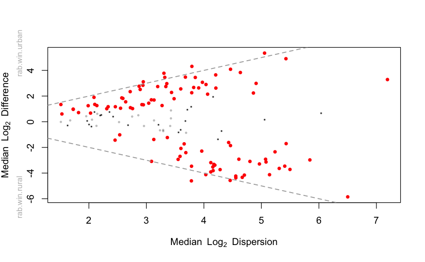

```r
# Extract CLR-normalized counts
aldex2_clr_s_cts <- aldex2_cts(aldex2_clr_s)
aldex2_clr_g_cts <- aldex2_cts(aldex2_clr_g)
aldex2_clr_f_cts <- aldex2_cts(aldex2_clr_f)
aldex2_clr_o_cts <- aldex2_cts(aldex2_clr_o)
aldex2_clr_c_cts <- aldex2_cts(aldex2_clr_c)
aldex2_clr_p_cts <- aldex2_cts(aldex2_clr_p)

# df of results
aldex2_clr_s_res <- aldex2_res(aldex2_clr_s)
aldex2_clr_g_res <- aldex2_res(aldex2_clr_g)
aldex2_clr_f_res <- aldex2_res(aldex2_clr_f)
aldex2_clr_o_res <- aldex2_res(aldex2_clr_o)
aldex2_clr_c_res <- aldex2_res(aldex2_clr_c)
aldex2_clr_p_res <- aldex2_res(aldex2_clr_p)

# sig results only
aldex2_clr_s_sig <- aldex2_sig(aldex2_clr_s_res, "s")
aldex2_clr_g_sig <- aldex2_sig(aldex2_clr_g_res, "g")
aldex2_clr_f_sig <- aldex2_sig(aldex2_clr_f_res, "f")
aldex2_clr_o_sig <- aldex2_sig(aldex2_clr_o_res, "o")
aldex2_clr_c_sig <- aldex2_sig(aldex2_clr_c_res, "c")
aldex2_clr_p_sig <- aldex2_sig(aldex2_clr_p_res, "p")

# bind sig results
aldex2_clr_all_sig <- rbind(aldex2_clr_s_sig, aldex2_clr_g_sig) %>%
  rbind(aldex2_clr_f_sig) %>%
  rbind(aldex2_clr_o_sig) %>%
  rbind(aldex2_clr_c_sig) %>%
  rbind(aldex2_clr_p_sig)

#write.csv(aldex2_clr_all_sig, "results/docs/DA_microbe_aldex2.csv")

# plot
aldex2_plot(aldex2_clr_s_res)
```

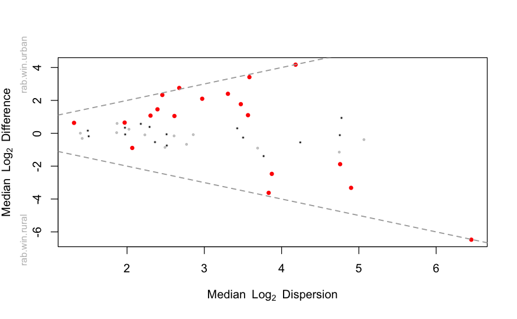

```r
aldex2_plot(aldex2_clr_g_res)
```

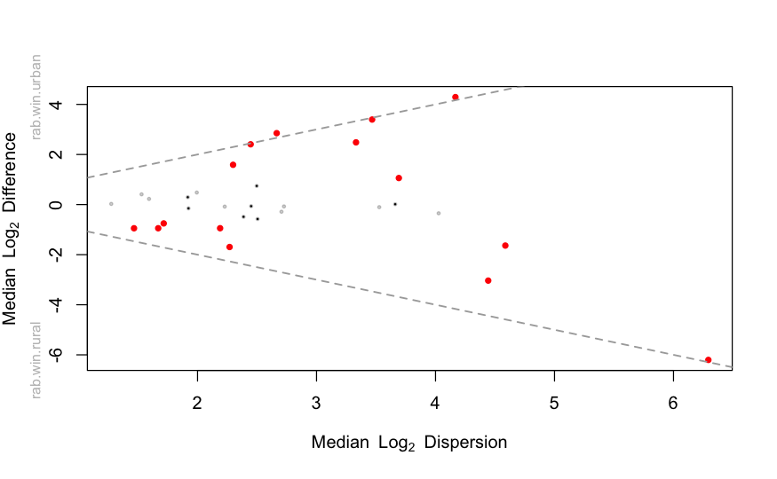

```r
aldex2_plot(aldex2_clr_f_res)
```

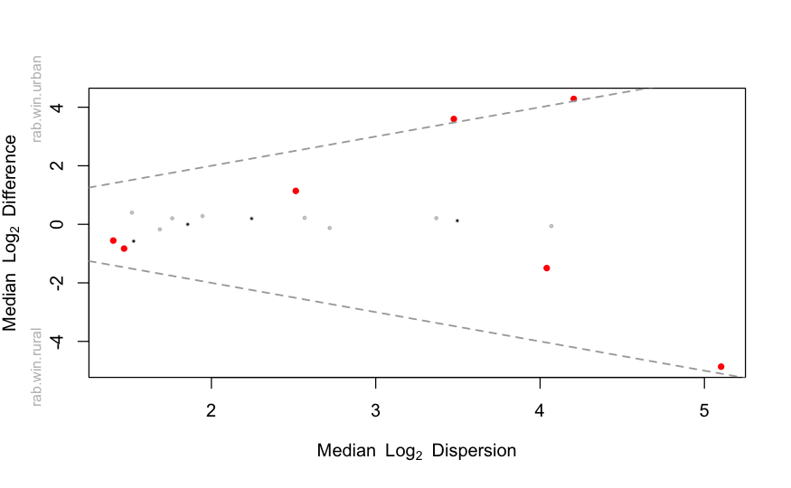

```r
aldex2_plot(aldex2_clr_o_res)
```

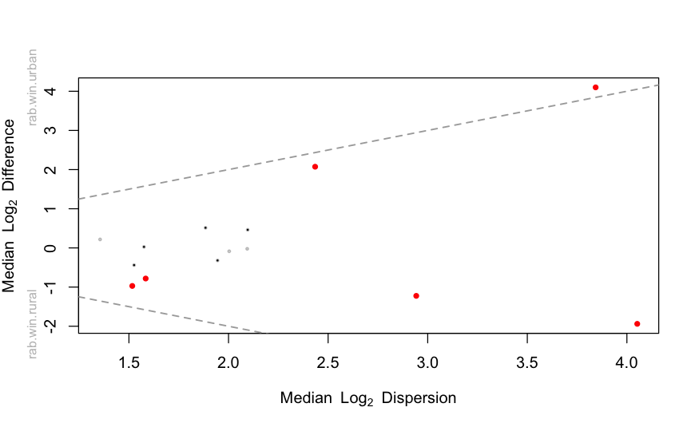

```r
aldex2_plot(aldex2_clr_c_res)
```

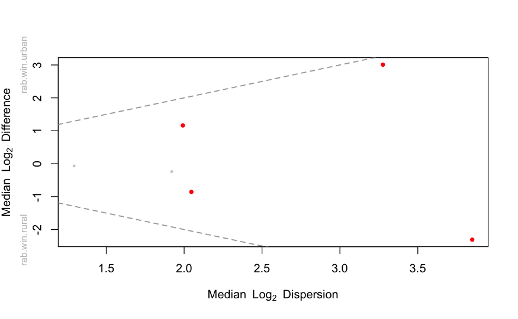

```r
aldex2_plot(aldex2_clr_p_res)
```

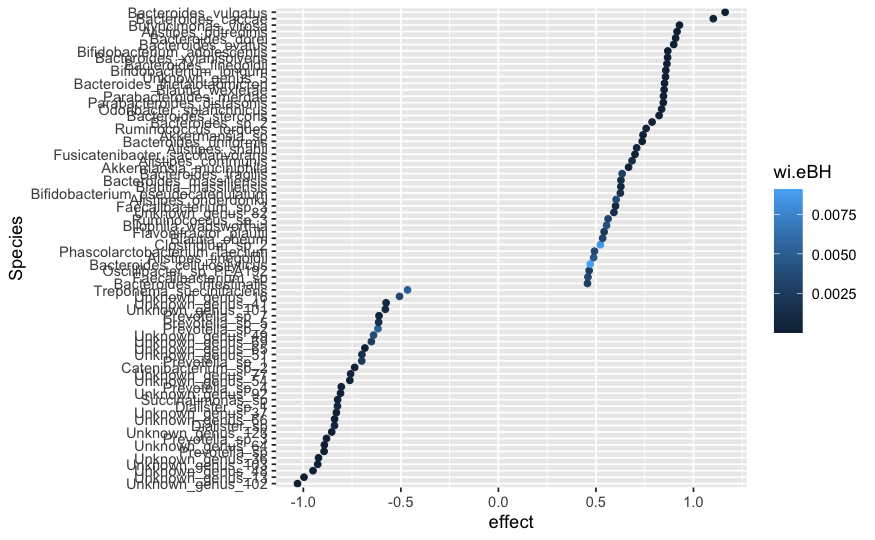

```r
da_s <- aldex2_clr_s_sig %>%
  rownames_to_column("Species") %>%
  arrange(effect)
da_s$Species <- factor(da_s$Species, levels = unlist(da_s$Species))

ggplot(da_s, aes(x=effect, y=Species)) +
  geom_point(aes(color=wi.eBH))
```

Apply CLR transformed values to phyloseq objects

```r
phy_clr_filt_s <- phy_filt_s
otu_table(phy_clr_filt_s) <- otu_table(aldex2_clr_s_cts, taxa_are_rows = T)

phy_clr_filt_g <- phy_filt_g
otu_table(phy_clr_filt_g) <- otu_table(aldex2_clr_g_cts, taxa_are_rows = T)

phy_clr_filt_f <- phy_filt_f
otu_table(phy_clr_filt_f) <- otu_table(aldex2_clr_f_cts, taxa_are_rows = T)

phy_clr_filt_o <- phy_filt_o
otu_table(phy_clr_filt_o) <- otu_table(aldex2_clr_o_cts, taxa_are_rows = T)

phy_clr_filt_c <- phy_filt_c
otu_table(phy_clr_filt_c) <- otu_table(aldex2_clr_c_cts, taxa_are_rows = T)

phy_clr_filt_p <- phy_filt_p
otu_table(phy_clr_filt_p) <- otu_table(aldex2_clr_p_cts, taxa_are_rows = T)

paste("ALDEx2 significant OTUs:",nrow(aldex2_clr_all_sig))
```

```
[1] "ALDEx2 significant OTUs: 109"
```

Make a list of the microbes we will look at downstream (if differentially abundant)

```r
# Combine significant results
clr_filt <- rbind(aldex2_clr_p_cts, aldex2_clr_c_cts) %>%
  rbind(aldex2_clr_o_cts) %>%
  rbind(aldex2_clr_f_cts) %>%
  rbind(aldex2_clr_g_cts) %>%
  rbind(aldex2_clr_s_cts)

clr_filt_DA <- clr_filt[row.names(aldex2_clr_all_sig),]

paste("pre-filt:",nrow(clr_filt))
```

```
[1] "pre-filt: 253"
```

```r
paste("post-filt:",nrow(clr_filt_DA))
```

```
[1] "post-filt: 109"
```

Save species and genus level abundances

```r
clr_filt_microbe_abundances <- clr_filt %>%
  t() %>%
  data.frame()

write.csv(clr_filt_microbe_abundances, "results/docs/clr_filt_microbe_abundances.csv")

clr_filt_DA_microbe_abundances <- clr_filt_DA %>%
  t() %>%
  data.frame()

write.csv(clr_filt_DA_microbe_abundances, "results/docs/clr_filt_DA_microbe_abundances.csv")
```

Just for comparison, lets also do a clr transformation of the phyloseq data

```r
phy_clr <- function(phy){
  microbiome::transform(phy, "clr")
}

phy_clr_cts <- function(phy){
  cts <- as.data.frame(otu_table(phy))
}

# transform
phy_clr_s <- phy_clr(phy_filt_s)
phy_clr_g <- phy_clr(phy_filt_g)
phy_clr_f <- phy_clr(phy_filt_f)
phy_clr_o <- phy_clr(phy_filt_o)
phy_clr_c <- phy_clr(phy_filt_c)
phy_clr_p <- phy_clr(phy_filt_p)

# counts matrix
phy_clr_s_cts <- phy_clr_cts(phy_clr_s)
phy_clr_g_cts <- phy_clr_cts(phy_clr_g)
phy_clr_f_cts <- phy_clr_cts(phy_clr_f)
phy_clr_o_cts <- phy_clr_cts(phy_clr_o)
phy_clr_c_cts <- phy_clr_cts(phy_clr_c)
phy_clr_p_cts <- phy_clr_cts(phy_clr_p)

DA_microbe_abundances_phyclr <- rbind(phy_clr_s_cts, phy_clr_g_cts) %>%
  rbind(phy_clr_f_cts) %>%
  rbind(phy_clr_o_cts) %>%
  rbind(phy_clr_c_cts) %>%
  rbind(phy_clr_p_cts) %>%
  t() %>%
  data.frame %>%
  dplyr::select(row.names(aldex2_clr_all_sig))

write.csv(DA_microbe_abundances_phyclr, "results/docs/DA_microbe_abundances_phyclr.csv")
```

```r
heatmap(as.matrix(DA_microbe_abundances))
```

[output not shown]

Post-filt distance matrix: species-level

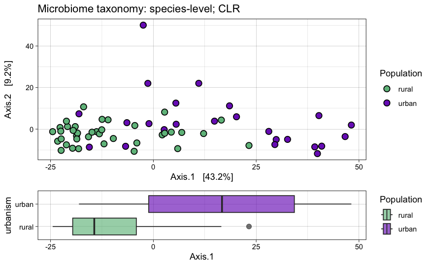

```r
# Distance matrix
species_clr_dist <- ordinate(phy_clr_filt_s, distance="euclidean", method="PCoA") #"RDA"
# Gives position of every sample along first 36 axes
species_clr_dist_vectors <- species_clr_dist$vectors

species_clr_dist_select <- species_clr_dist_vectors %>%
  as.data.frame() %>%
  dplyr::select(c("Axis.1", "Axis.2")) %>%
  rownames_to_column("SampleName") %>%
  merge(meta[c("SampleID","SampleName","urbanism", "urbanism2", "country", "Shannon")], by="SampleName")

species_clr_dist_pcoa <- plot_ordination(phy_clr_filt_s, species_clr_dist, type="sample") +
  geom_point(aes(fill=urbanism), shape=21, size=3, stroke = 0.75) +
  scale_fill_manual(values=c("#6FBD8B", "#7B2BC1"), name = "Population") + #F42585
  theme_linedraw() +
  #ylab("PC2: 13.5%") +
  ggtitle("Microbiome taxonomy: species-level; CLR") #+
  #theme(axis.title.x = element_blank())

#library(ggimage)
#species_clr_dist_pcoa_country <- plot_ordination(phy_clr_filt_s, species_clr_dist, type="sample") +
#  geom_image(aes(image=image), size=.05) +
#  geom_point(aes(fill=urbanism), shape=21, size=3, stroke = 0.75) +
  #scale_fill_manual(values=c("#6FBD8B", "#7B2BC1"), name = "Population") + #F42585
#  theme_linedraw() +
  #ylab("PC2: 13.5%") +#
  #ggtitle("Microbiome taxonomy: species-level; CLR") #+
  #theme(axis.title.x = element_blank())

#species_clr_dist_pcoa_country

species_clr_dist_urbanism <- ggplot(species_clr_dist_select, aes(x=Axis.1, y=urbanism, fill=urbanism)) +
  geom_boxplot(alpha=0.65, outlier.size = 2.5) +
  scale_fill_manual(values=c("#6FBD8B", "#7B2BC1"), name = "Population") + #F42585
  theme_linedraw() #+
  #xlab("PC1: 23.3%") +
  #theme(axis.title.y = element_blank(), axis.text.y = element_blank(), axis.ticks.y = element_blank())

#species_clr_dist_country <- ggplot(species_clr_dist_select, aes(x=Axis.1, y=country, fill=country)) +
#  geom_boxplot(alpha=0.65, outlier.size = 2.5) +
  #scale_fill_manual(values=c("#6FBD8B", "#7B2BC1"), name = "Population") + #F42585
#  theme_linedraw()

ggarrange(species_clr_dist_pcoa, species_clr_dist_urbanism, ncol=1, align = "v", heights=c(0.7, 0.3))
```

```r
#ggsave("results/figs/metaG-PCoA/species.png", width=5, height=4)
```

Post-filt distance matrix: genus-level

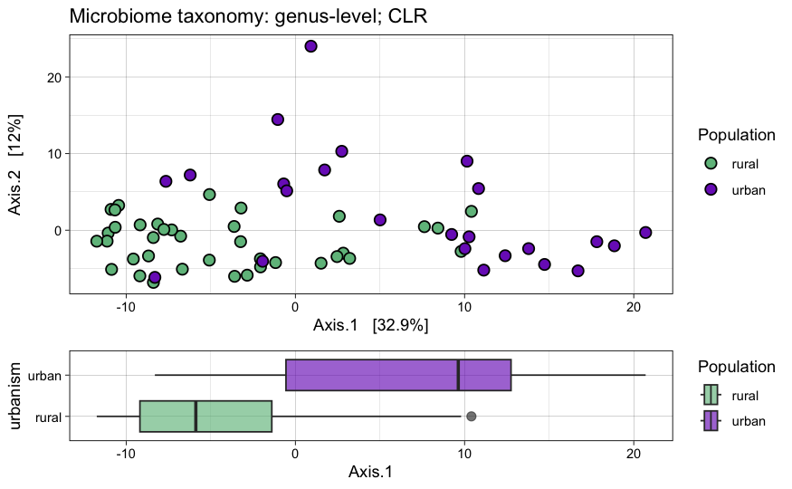

```r
# Distance matrix
genus_clr_dist <- ordinate(phy_clr_filt_g, distance="euclidean", method="PCoA") #"RDA"
# Gives position of every sample along first 36 axes
genus_clr_dist_vectors <- genus_clr_dist$vectors

genus_clr_dist_select <- genus_clr_dist_vectors %>%
  as.data.frame() %>%
  dplyr::select(c("Axis.1", "Axis.2")) %>%
  rownames_to_column("SampleName") %>%
  merge(meta[c("SampleID","SampleName","urbanism", "urbanism2", "country", "Shannon")], by="SampleName")

genus_clr_dist_pcoa <- plot_ordination(phy_clr_filt_g, genus_clr_dist, type="sample") +
  geom_point(aes(fill=urbanism), shape=21, size=3, stroke = 0.75) +
  scale_fill_manual(values=c("#6FBD8B", "#7B2BC1"), name = "Population") + #F42585
  theme_linedraw() +
  #ylab("PC2: 13.5%") +
  ggtitle("Microbiome taxonomy: genus-level; CLR") #+
  #theme(axis.title.x = element_blank())

#library(ggimage)
#species_clr_dist_pcoa_country <- plot_ordination(phy_clr_filt_s, species_clr_dist, type="sample") +
#  geom_image(aes(image=image), size=.05) +
#  geom_point(aes(fill=urbanism), shape=21, size=3, stroke = 0.75) +
  #scale_fill_manual(values=c("#6FBD8B", "#7B2BC1"), name = "Population") + #F42585
#  theme_linedraw() +
  #ylab("PC2: 13.5%") +#
  #ggtitle("Microbiome taxonomy: species-level; CLR") #+
  #theme(axis.title.x = element_blank())

#species_clr_dist_pcoa_country

genus_clr_dist_urbanism <- ggplot(genus_clr_dist_select, aes(x=Axis.1, y=urbanism, fill=urbanism)) +
  geom_boxplot(alpha=0.65, outlier.size = 2.5) +
  scale_fill_manual(values=c("#6FBD8B", "#7B2BC1"), name = "Population") + #F42585
  theme_linedraw() #+
  #xlab("PC1: 23.3%") +
  #theme(axis.title.y = element_blank(), axis.text.y = element_blank(), axis.ticks.y = element_blank())

#species_clr_dist_country <- ggplot(species_clr_dist_select, aes(x=Axis.1, y=country, fill=country)) +
#  geom_boxplot(alpha=0.65, outlier.size = 2.5) +
  #scale_fill_manual(values=c("#6FBD8B", "#7B2BC1"), name = "Population") + #F42585
#  theme_linedraw()

ggarrange(genus_clr_dist_pcoa, genus_clr_dist_urbanism, ncol=1, align = "v", heights=c(0.7, 0.3))
```

```r
#ggsave("results/figs/metaG-PCoA/species.png", width=5, height=4)
```

Relative abundance transformations for plotting purposes.

```r
# Transform to relative abundance
phy_r_filt_s = transform_sample_counts(phy_filt_s,function(x){x / sum(x)})
phy_r_filt_g = transform_sample_counts(phy_filt_g,function(x){x / sum(x)})
phy_r_filt_f = transform_sample_counts(phy_filt_f,function(x){x / sum(x)})
phy_r_filt_o = transform_sample_counts(phy_filt_o,function(x){x / sum(x)})
phy_r_filt_c = transform_sample_counts(phy_filt_c,function(x){x / sum(x)})
phy_r_filt_p = transform_sample_counts(phy_filt_p,function(x){x / sum(x)})
# CLR transformation
#phy_clr_filt_s <- microbiome::transform(phy_filt_s, "clr")
#phy_clr_filt_g <- microbiome::transform(phy_filt_g, "clr")
```

Genus barplot

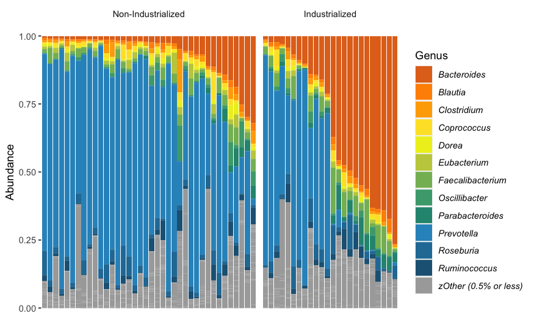

```r
g_plot_df <- phy_r_filt_g %>%
  psmelt() %>%
  dplyr::select(g, Abundance) %>%
  group_by(g) %>%
  summarize(median = median(Abundance)) %>%
  left_join(psmelt(phy_r_filt_g), by = "g") %>%
  # Set threshold for "Other" coloring
  mutate(Genus = case_when(median < 0.005 ~ paste0('zOther (', 0.005*100, '% or less)'),
                             .default =g)) %>%
  mutate(SampleName = as.factor(SampleName))

# Sort according to bacteroides
bac_sort <- g_plot_df %>%
  subset(Genus == "Bacteroides") %>%
  arrange(Abundance)
g_plot_df$SampleName <- factor(g_plot_df$SampleName, levels = unlist(bac_sort$SampleName))

g_plot <- ggplot(g_plot_df, aes(x=SampleName, y=Abundance, fill=Genus)) +
  #geom_point(aes(x=SampleName, y= 1.02, color=shreya_samps)) +
  #scale_color_manual(values=c("white", "red")) +
  geom_bar(aes(), stat="identity", position="stack") +
  scale_fill_manual(values=c(
    "#e2711d", # Bacteroides
    "#ff9100", # Blautia
    "#ffaa00", # Clostridium
    "#fee231", # Coprococcus
    "#eeef20", # Dorea
    "#c2cd4b", # Eubacterium
    "#84ba63", # Faecalibacterium
    "#4aa77c", # Oscillibacter
    "#28947f", # Parabacteroides
    "#2f94c6", # Prevotella
    "#277ba5", # Roseburia
    "#1f6284", # Ruminococcus
    "darkgrey"# Other
  )) +
  facet_grid(~urbanism, scales="free", space="free", labeller = as_labeller(c(rural="Non-Industrialized", urban="Industrialized"))) +
  theme(
    panel.background = element_rect(fill = "transparent"), # bg of the panel
    plot.background = element_rect(fill = "transparent", color = NA), # bg of the plot
    panel.grid.major = element_blank(), # get rid of major grid
    panel.grid.minor = element_blank(), # get rid of minor grid
    legend.background = element_rect(fill = "transparent"), # get rid of legend bg
    legend.box.background = element_rect(fill = "transparent", color=NA), # get rid of legend panel bg and border
    legend.text = element_text(face = "italic"),
    #legend.position="bottom",
    axis.title.x = element_blank(),
    axis.text.x = element_blank(),
    axis.ticks.x = element_blank(),
    strip.background =element_rect(fill=NA,))

g_plot
```

```r
#ggsave("results/figs/metaG-stackedbar/genus.png", width=6.5, height=4)
```

```r
g_plot_df2 <- phy_r_filt_g %>%
  psmelt() %>%
  dplyr::select(g, Abundance) %>%
  group_by(g) %>%
  summarize(median = median(Abundance)) %>%
  left_join(psmelt(phy_r_filt_g), by = "g") %>%
  # Set threshold for "Other" coloring
  mutate(Genus = case_when(median < 0.005 ~ paste0('zOther (', 0.005*100, '% or less)'),
                             .default =g)) %>%
  mutate(SampleName = as.factor(SampleName))

s_res_ggplot <- aldex2_clr_s_res %>%
  rownames_to_column("s") %>%
  arrange(effect) %>%
  mutate(sig = case_when(((wi.eBH < 0.005) & (effect > 0.8)) | ((wi.eBH < 0.005) & (effect < 0.8)) ~ "sig",
                         FALSE ~ "ns")) %>%
  merge(taxonomy_sep_select[,c("s","g")], by="s") %>%
  merge(g_plot_df2[,c("g","Genus")], by="g")

species_of_interest <- c("Bacteroides_vulgatus", "Alistipes_putredinis", "Faecalibacterium_sp")

s_res_ggplot <- s_res_ggplot %>%
  mutate(name = case_when(s %in% species_of_interest ~ s,
                          FALSE ~ "")) %>%
  mutate(name = str_replace_all(name, "_", " ")) %>%
  mutate(shape = case_when(is.na(name) ~ "shape1",
                           TRUE ~ "shape2"))
```

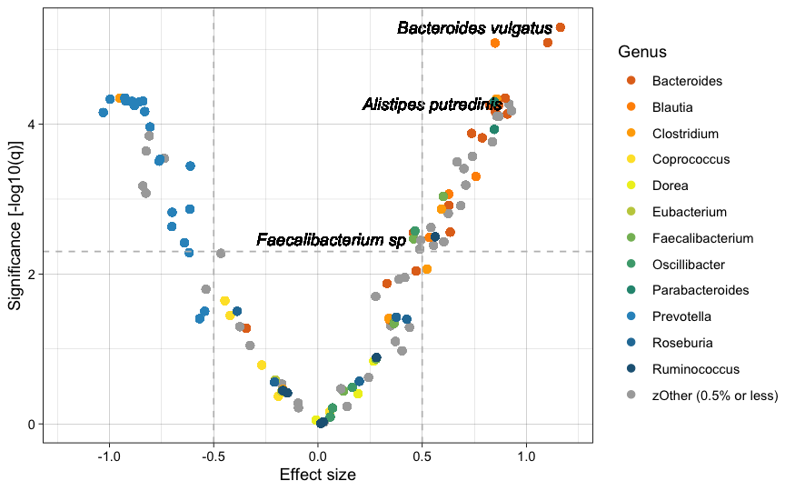

```r
ggplot(s_res_ggplot, aes(x=effect, y=-log10(wi.eBH), label=name)) +
  geom_point(aes(color=Genus), size=2) +
  geom_text(fontface = "italic", hjust =1.05) +
  xlab("Effect size") +
  ylab("Significance [-log10(q)]") +
  xlim(values=c(-1.2,1.2)) +
  geom_hline(yintercept = -log10(0.005), linetype = "dashed", color = "gray") +
  geom_vline(xintercept = c(-0.5, 0.5), linetype = "dashed", color = "gray") +
  scale_color_manual(values=c(
    "#e2711d", # Bacteroides
    "#ff9100", # Blautia
    "#ffaa00", # Clostridium
    "#fee231", # Coprococcus
    "#eeef20", # Dorea
    "#c2cd4b", # Eubacterium
    "#84ba63", # Faecalibacterium
    "#4aa77c", # Oscillibacter
    "#28947f", # Parabacteroides
    "#2f94c6", # Prevotella
    "#277ba5", # Roseburia
    "#1f6284", # Ruminococcus
    "darkgrey"# Other
  )) +
  theme_linedraw()
ggsave("results/figs/volcano_f31.png", width=6, height=4)
```

Species barplot

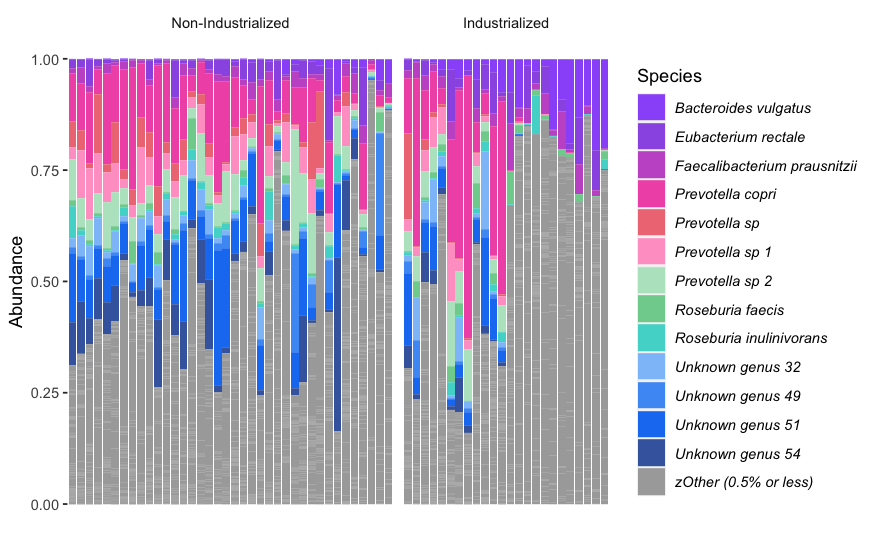

```r
s_plot_df <- phy_r_filt_s %>%
  psmelt() %>%
  dplyr::select(s, Abundance) %>%
  group_by(s) %>%
  summarize(median = median(Abundance)) %>%
  left_join(psmelt(phy_r_filt_s), by = "s") %>%
  # Set threshold for "Other" coloring
  mutate(Species = case_when(median < 0.005 ~ paste0('zOther (', 0.005*100, '% or less)'),
                             .default = s)) %>%
  mutate(Species = str_replace_all(Species, "_", " ")) %>%
  mutate(SampleName = as.factor(SampleName))

# Sort in same order as genus
s_plot_df$SampleName <- factor(s_plot_df$SampleName, levels = unlist(bac_sort$SampleName))

s_plot <- ggplot(s_plot_df, aes(x=SampleName, y=Abundance, fill=Species)) +
  #geom_point(aes(x=SampleName, y= 1.02, color=shreya_samps)) +
  #scale_color_manual(values=c("white", "red")) +
  geom_bar(aes(), stat="identity", position="stack") +
    scale_fill_manual(values=c(
    "#9b5ef9", # Bacteroides vulgatus
    "#9b5de5", # Bacteroides vulgatus
    "#c65ccd", # Eubacterium rectale
    "#f15bb5", # Faecalibacterium prausnitzii
    "#ef7a85", # Prevotella copri
    "#ffa2cb", # Prevotella sp
    "#b7e4c7", # Prevotella sp 1
    "#7fd09d", # Prevotella sp 2
    "#50d7d0", # Roseburia faecis
    "#8ec2f9", # Unknown 32
    "#4c9bf5", # Unknown 49
    "#1a7ef2", # Unknown 51
    "#4267ac", # Unknown 54
    "darkgrey"# Other
  )) +
  facet_grid(~urbanism, scales="free", space="free", labeller = as_labeller(c(rural="Non-Industrialized", urban="Industrialized"))) +
  theme(
    panel.background = element_rect(fill = "transparent"), # bg of the panel
    plot.background = element_rect(fill = "transparent", color = NA), # bg of the plot
    panel.grid.major = element_blank(), # get rid of major grid
    panel.grid.minor = element_blank(), # get rid of minor grid
    legend.background = element_rect(fill = "transparent"), # get rid of legend bg
    legend.box.background = element_rect(fill = "transparent", color=NA), # get rid of legend panel bg and border
    legend.text = element_text(face = "italic"),
    axis.title.x = element_blank(),
    axis.text.x = element_blank(),
    axis.ticks.x = element_blank(),
    strip.background =element_rect(fill=NA,))
s_plot
```

```r
#ggsave("results/figs/metaG-stackedbar/species.png", width=6.5, height=4)
```

Now let’s prepare the data we will use to export and test in DESeq. We will save the taxa with (1) highest median abundance, (2) significant differential abundance in urban vs. rural, and (3) strongest associations with PC1-microbiome.  
Medians

```r
medians_s <- phy_clr_filt_s %>%
  otu_table() %>%
  as.data.frame() %>%
  rownames_to_column("s") %>%
  rowwise() %>%
  mutate(median = median(c_across(where(is.numeric)))) %>%
  ungroup() %>%
  dplyr::arrange(desc(median)) %>%
  dplyr::top_n(30) %>%
  dplyr::select(s) %>%
  unlist()
medians_g <- phy_clr_filt_g %>%
  otu_table() %>%
  as.data.frame() %>%
  rownames_to_column("g") %>%
  rowwise() %>%
  mutate(median = median(c_across(where(is.numeric)))) %>%
  ungroup() %>%
  dplyr::arrange(desc(median)) %>%
  dplyr::top_n(30) %>%
  dplyr::select(g) %>%
  unlist()
```

Associations with PC1-microbiome

```r
# species
pc1_s <- species_clr_dist_vectors %>%
  as.data.frame() %>%
  dplyr::select(Axis.1) %>%
  merge(t(as.data.frame(otu_table(phy_clr_filt_s))), by="row.names") %>%
  column_to_rownames("Row.names")

pc1cor_s <- apply(pc1_s[, colnames(pc1_s)], 2, function(x) {
  result <- cor.test(x, unlist(pc1_s$Axis.1))
  result$conf.int <- NULL
  return(result)
})
pc1cor_s <- data.table::rbindlist(pc1cor_s, fill=TRUE, idcol = TRUE) %>%
  dplyr::rename(s=.id) %>%
  dplyr::filter(!s=="Axis.1") %>%
  filter(p.value < 0.05)

pc1cor_s <- c(list(pc1cor_s),
              list(dplyr::filter(pc1cor_s, estimate < 0)),
              list(dplyr::filter(pc1cor_s, estimate > 0)))
pc1cor_s <- pc1cor_s %>% lapply(dplyr::select, s)
pc1cor_s <- pc1cor_s %>% lapply(unlist)
names(pc1cor_s) <- c("all", "rural", "urban")

# genus
pc1_g <- genus_clr_dist_vectors %>%
  as.data.frame() %>%
  dplyr::select(Axis.1) %>%
  merge(t(as.data.frame(otu_table(phy_clr_filt_g))), by="row.names") %>%
  column_to_rownames("Row.names")

pc1cor_g <- apply(pc1_g[, colnames(pc1_g)], 2, function(x) {
  result <- cor.test(x, unlist(pc1_g$Axis.1))
  result$conf.int <- NULL
  return(result)
})
pc1cor_g <- data.table::rbindlist(pc1cor_g, fill=TRUE, idcol = TRUE) %>%
  dplyr::rename(g=.id) %>%
  dplyr::filter(!g=="Axis.1") %>%
  filter(p.value < 0.05)

pc1cor_g <- c(list(pc1cor_g),
              list(dplyr::filter(pc1cor_g, estimate < 0)),
              list(dplyr::filter(pc1cor_g, estimate > 0)))
pc1cor_g <- pc1cor_g %>% lapply(dplyr::select, g)
pc1cor_g <- pc1cor_g %>% lapply(unlist)
names(pc1cor_g) <- c("all", "rural", "urban")
```

Test differential abundance and generate candidate taxa for testing in DESeq2 (colonocyte RNA seq). ALDEx2 works great for CLR-transformed data. https://www.nicholas-ollberding.com/post/introduction-to-the-statistical-analysis-of-microbiome-data-in-r/

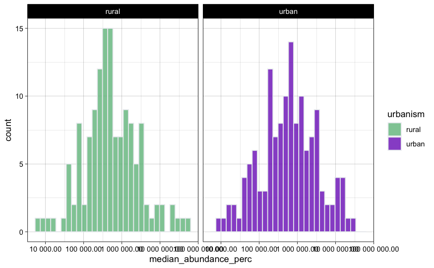

```r
# Convert OTU table and sample data to data frames
aldex2_otu <- data.frame(phyloseq::otu_table(phy_filt_s))
colnames(aldex2_otu) <- sub("^X", "", colnames(aldex2_otu))
aldex2_otu2 <- aldex2_otu %>%
  t() %>%
  as.data.frame() %>%
  rownames_to_column("SampleName")

aldex2_samp <- phyloseq::sample_data(phy_clr_filt_s)
aldex2_samp2 <- aldex2_samp %>%
  data.frame() %>%
  dplyr::select(SampleName, urbanism)

# Combine and summarize data
aldex2_summ <- aldex2_otu2 %>%
  inner_join(aldex2_samp2, by = "SampleName") %>%
  group_by(urbanism) %>%
  summarize(across(everything(), median)) %>%
  dplyr::select(-SampleName)
# Reshape the data
aldex2_summ <- aldex2_summ %>%
  pivot_longer(cols = -urbanism, names_to = "OTU", values_to = "median_abundance") %>%
  mutate(median_abundance = as.numeric(median_abundance), median_abundance_perc = median_abundance * 100)

ggplot(aldex2_summ, aes(x=median_abundance_perc, fill=urbanism)) +
  geom_histogram( color="#e9ecef", alpha=0.8, position = 'identity') +
  scale_fill_manual(values=c("#6FBD8B", "#7B2BC1")) +
  #scale_y_log10() +
  scale_x_log10(labels = scales::number_format(accuracy = 0.01)) +
  theme_linedraw() +
  facet_wrap(~urbanism)
```

```r
# Based on histogram, let's limit the taxa to those with an abundance > 0.1%
aldex2_summ_filt <- aldex2_summ %>%
  dplyr::filter(median_abundance_perc > 0.1)

aldex2_otu_filt <- aldex2_otu %>%
  dplyr::filter(row.names(aldex2_otu) %in% unique(aldex2_summ_filt$OTU))

# ALL VALUES NEED TO BE INTEGERS
aldex2_da_s <- ALDEx2::aldex(aldex2_otu_filt, aldex2_samp$urbanism, test="t", effect = TRUE, denom="iqlr")
```

```
aldex.clr: generating Monte-Carlo instances and clr values
operating in serial mode
computing iqlr centering
aldex.ttest: doing t-test
aldex.effect: calculating effect sizes
```

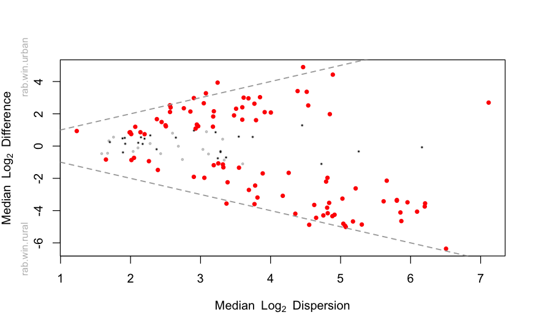

```r
ALDEx2::aldex.plot(aldex2_da_s, type="MW", test="wilcox", called.cex = 1, cutoff = 0.05)
```

```r
# EASIER TO INPUT ALL DATA, THEN FILTER THE DIFFERENTIAL ABUNDANCE RESULTS FOR TAXA WITH RA > 0.1%
# NEED TO INPUT RAW COUNTS

# Suggestion from marco: (1) minimum prevlaence filtering, (2) aldex for CLR and TSS (3) get clr differential abundance data (4) use TSS for making a stacked bar plot (5) filter differential abundance results for abundance

sig_aldex2_s <- aldex2_da_s %>%
  rownames_to_column(var = "s") %>%
  filter(wi.eBH < 0.05) %>%
  arrange(effect, wi.eBH) %>%
  dplyr::select(s, diff.btw, diff.win, effect, wi.ep, wi.eBH)
head(sig_aldex2_s)
```

|  | s | diff.btw | diff.win | effect | wi.ep | wi.eBH |
| --- | --- | --- | --- | --- | --- | --- |
| 1 | Unknown_genus_48 | -3.564821 | 3.370441 | -0.9986290 | 4.470507e-07 | 1.648354e-05 |
| 2 | Unknown_genus_102 | -4.879352 | 4.551675 | -0.9575978 | 8.142709e-06 | 9.922396e-05 |
| 3 | Unknown_genus_103 | -4.934160 | 5.063469 | -0.9381512 | 4.213666e-06 | 8.206102e-05 |
| 4 | Unknown_genus_36 | -5.013516 | 5.074201 | -0.9084938 | 6.289870e-06 | 8.921153e-05 |
| 5 | Unknown_genus_13 | -4.444971 | 4.650689 | -0.8991884 | 5.321951e-06 | 8.512707e-05 |
| 6 | Prevotella_sp | -4.862790 | 5.302951 | -0.8955517 | 1.304243e-05 | 1.215685e-04 |

```r
aldex2_da_g <- ALDEx2::aldex(data.frame(phyloseq::otu_table(phy_filt_g)), phyloseq::sample_data(phy_filt_g)$urbanism, test="t", effect = TRUE, denom="iqlr")
```

```
aldex.clr: generating Monte-Carlo instances and clr values
operating in serial mode
computing iqlr centering
aldex.ttest: doing t-test
aldex.effect: calculating effect sizes
```

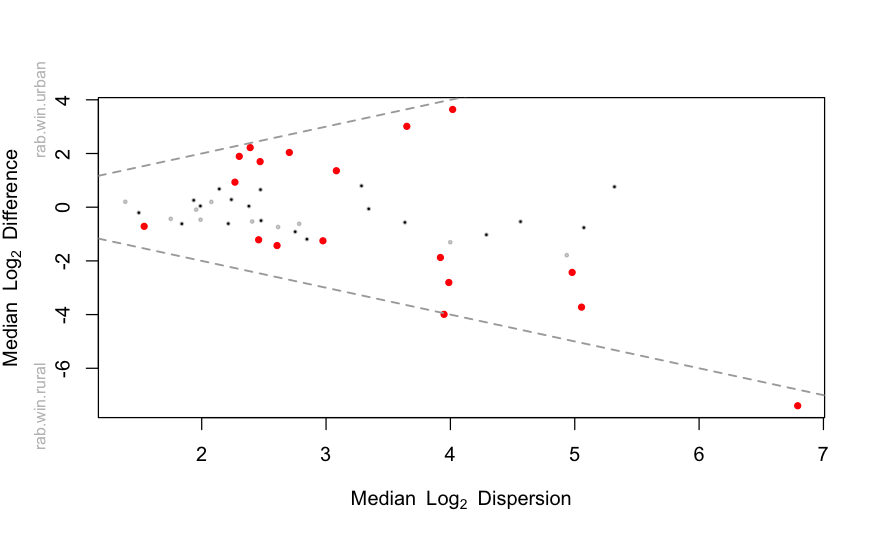

```r
ALDEx2::aldex.plot(aldex2_da_g, type="MW", test="wilcox", called.cex = 1, cutoff = 0.05)
```